# STK4900 - Statistical Methods and Applications

# Lecture 4

## Topics

1. Causal effects
2. Confounding
3. Interaction
4. More on ANOVA
5. Prediction

https://www.uio.no/studier/emner/matnat/math/STK4900/v21/lectures/lecture4.pdf

## Causal effects and Confounding

We are closer to identifying causality after adjusting (or controlling) for known confounders.

A covariate $X_2$ is a confounder for the causal effect of $X_1$ provided that: * $X_2$ is a plausible cause of the outcome Y * $X_2$ is a plausible cause of predictor $X_1$

We can control for confounding covariates by fitting a linear model,
$$y_i = \beta_0 + \beta_1x_{1i} + \beta_2x_{2i}+\epsilon_i,$$
$$E(Y) = \alpha + \beta_1x_{1} + \beta_2x_{2} \quad (1) \\
\text{omitting variable } x_2: \\
E(Y) = \alpha + bx_{1} \quad (2) \\
\hat{b} \text{, the least squares estimate of b under model (2):} \\
\hat{b} = \hat{\beta}_1 + \hat{\beta}_2r_{12}\frac{s_2}{s_1} \quad (3) \\
therefore, \space if \space r_{12} = 0 \rightarrow \hat{b} \approx \hat{\beta}_1$$

```r
# hers.nob=hers.no[!is.na(hers.no$BMI),]
# fit.a=lm(glucose~exercise,data=hers.nob)
# fit.a$coef
```

```r
# fit.b=lm(glucose~exercise+BMI,data=hers.nob)
# fit.b$coef
```

```r
# fit.b$coef[2] + fit.b$coef[3] * cor(hers.nob$exercise, hers.nob$BMI) * s2/s1 * sd(hers.nob$BMI) / sd(hers.nob$exercise)
# = fit.a$coef
```

## Mediation

We should not adjust for variables that are intermediate variables (likely correlated to one variable and causally related to outome)

ie. adjusting for cholesterol measured after taking statins may then hide a causal effect of statins on risk of heart attact (statin -> lower cholesterol -> reduced risk of heart attack)

## Randomization

Randomization allows us to ignore confounding variables and estimate causation:
$$corr(treatment \space x_1, confounder \space x_2) = 0 \rightarrow r \approx 0, \hat{b} \approx \hat{\beta}_1$$

## Interaction (15)

Occurs when the effect of a covariate $X_1$ depends on the level of $X_2$.

NB. Useful to center numerical covariates by subtracting the mean to ease interpretation.

### Binary covariates

```r
## hers = read.table('https://www.uio.no/studier/emner/matnat/math/STK4900/data/hers.txt', header = T)
## ht.fit=lm(LDL1~HT+statins+HT:statins, data=hers)
## summary(ht.fit)
```

Note: HT:statin specifies the interaction term "HT*statin".

- $X_1$ reduces Y for $X_2 = 0 \space by \space \hat{\beta}_1$
- $X_2$ reduces Y by $\hat{\beta}_2$
- $X_1$ reduces Y for $X_2 = 1$ by $\hat{\beta}_{X_1:X_2}$

```r
## library(contrast)
## par1= list(HT=1,statins=1) # specify one set of values of the covariates
## par2= list(HT=0,statins=1) # specify another set of values of the covariates
## contrast(ht.fit, par1,par2) # compute the difference between the two sets
```

Another options for interpretating interactions can be to construct a new categorical variabel with one level for each combination of levels of the original factors.

```r
## hers$HTstat=1*(hers$HT==0&hers$statins==0)+2*(hers$HT==1&hers$statins==0) +3*(hers$HT==0&hers$statins==1)+4*(hers$HT==1&hers$statins==1)
## hers$HTstat=factor(hers$HTstat)
## ht.fit.b=lm(LDL1~HTstat, data=hers)
## summary(ht.fit.b)
```

### One binary and one numerical covariate

Model with different intercepts and slopes for the numerical covariate depending on the value of the binary covariate.

$$\begin{align}
y_i &= \beta_0+\beta_1x_{1i}+\beta_2x_{2i}+\beta_3x_{1i}x_{2i}+\epsilon_i \\
&= \begin{cases}
\beta_0+\beta_2x_{2i}+\epsilon_i & when \space x_{1i}=0 \\
\beta_0+\beta_1+(\beta_2+\beta_3)x_{2i}+\epsilon_i & when \space x_{1i}=1 \\
\end{cases}
\end{align}$$

```r
## hers$cBMI=hers$BMI - mean(hers$BMI[!is.na(hers$BMI)])
## stat.fit=lm(LDL~statins+cBMI+statins:cBMI,data=hers)
## summary(stat.fit)
```

### Two numerical covariates

$$y_i = \beta_0+\beta_1x_{1i}+\beta_2x_{2i}+\beta_3x_{1i}x_{2i}+\epsilon_i$$

## ANOVA

### Two-way ANOVA

```r
## polymer=read.table("http://www.uio.no/studier/emner/matnat/math/STK4900/v11/polymer.txt",header=T)
## polymer$ftemp=factor(polymer$temp)
## polymer$fcat=factor(polymer$cat)
## fit=lm(rate~ftemp+fcat+ftemp:fcat,data=polymer)
## summary(fit)
```

### Balanced design

- Same number of observations for all the J*K combinations of levels of factor A and B.
- Allows for the total sum of squares to be uniquely decomposed as a sum of sqares for each of the two factors (SSA,SSB), a sum of squares for the interaction (SSAB), and a residual sum of squares (RSS):

$$TSS = SSA + SSB + SSAB + RSS$$

### Hypothesis testing

```r
## anova(fit)
```

$$H_0: all \space (\alpha\beta)_{jk} = 0 \quad (\text{no interaction}) \\
H_0: all \space \alpha_j = 0 \quad (\text{no main effect of A)} \\
H_0: all \space \beta_k = 0 \quad (\text{no main effect of A)} \\$$

### Higher level ANOVA

Data: $y_{ijkl} =$ observation number $i$ for level $a_j$ of factor A, level $b_k$ of factor B, and level $c_l$ of factor C.

Model with interaction
$$y_{ijkl} = \mu + \alpha_j + \beta_k + \gamma_l + (\alpha\beta)_{jk} + (\alpha\gamma)_{jl} + (\beta\gamma)_{kl} + (\alpha\beta\gamma)_{jkl} + \epsilon_{ijkl}$$

Hypothesis testing similar to two-way ANOVA.

## Expected values and prediction with new covariate (34)

Consider a new covariate vector $x^{new} = (x_1^{new}, x_2^{new}, ..., x_p^{new})$

Expectation and prediction of new outcome:

$$\mu_{new} = \beta_0 + \beta_1x_1^{new} + \beta_2x_2^{new} + ... + \beta_px_p^{new} \\
t = \frac{\hat{\mu^{new}}-\mu^{new}}{se(\hat{\mu^{new}})} \sim t_{n-p-1} \\$$

Confidence intervals for a new outcome:
$$\hat{\mu}^{new} \pm c*se(\hat{\mu}^{new})$$

Prediction intervals for a new outcome:
$$\hat{\mu}^{new} \pm c* \sqrt{s_{Y|x}^2 + se(\hat{\mu}^{new})^2}$$

c is a percentile i in the t-distribution with n-p-1 df.

### Simple linear regression

$$Var(\hat{\mu}^{new}) = \sigma_\epsilon^2(\frac{1}{n}+\frac{(x^{new}-\bar{x})^2}{\sum_i{(x_i-\bar{x})^2}})$$

Confidence interval for the expected value:

$$\hat{\mu}^{new} \pm c* \sqrt{\frac{1}{n}+\frac{(x^{new}-\bar{x})^2}{\sum_i{(x_i-\bar{x})^2}}}$$

Prediction intervals for a new outcome:

$$\hat{\mu}^{new} \pm c * \sqrt{1+\frac{1}{n}+\frac{(x^{new}-\bar{x})^2}{\sum_i{(x_i-\bar{x})^2}}}$$

```r
## sbpage=lm(sbp~age,data=hers.sample)
## age=45:80
## newage=as.data.frame(age)
## estsbp=predict(sbpage,newage,int="conf")
## predsbp=predict(sbpage,newage,int="pred")
```

# Lecture 5

## Topics

1. Checking model assumptions (2)
2. Selection of predictors (23)
3. Generalized Additive Models (GAM) (19)
4. High dimensional regression (33)

https://www.uio.no/studier/emner/matnat/math/STK4900/v21/lectures/lecture5.pdf

## Checking model assumptions

### Assumptions for linear regression

$$y_i = \eta_i + \epsilon_i$$

Plots of the residuals may be used to check:

1. Linearity
2. Constant variance
3. Normal errors

#### Linearity

$$\eta_i = \beta_0 + \beta_1x_{1i} + \beta_2x_{2i} + ... + \beta_px_{pi}$$
If the model is linear in all predictors, except the j-th:
$$\eta_i = \beta_0 + \beta_1x_{1i} + ... + \beta_{j-1}x_{j-1,i} + f_j(x_{ji})+\beta_{j+1}x_{j+1,i} ... + \beta_px_{pi}$$

We can estimate the function $f_j(x)$ with a CPR plot.

##### Check of linearity

Component-plus-residual (CPR) plot of the partial residuals, $\hat{\beta}_jx_{ji} + r_i$, versus the values of the predictor, $(x_{ji})$.

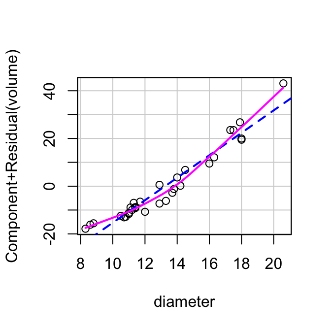

```r
### Fit a model w/ volume as outcome and diameter and height as predictors, and make a CPR plot for diameter:
fit.both=lm(volume~diameter+height, data=trees)

## The plot indicates that a second degree polynomial may be more appropriate:
crPlots(fit.both, terms=~diameter)
```

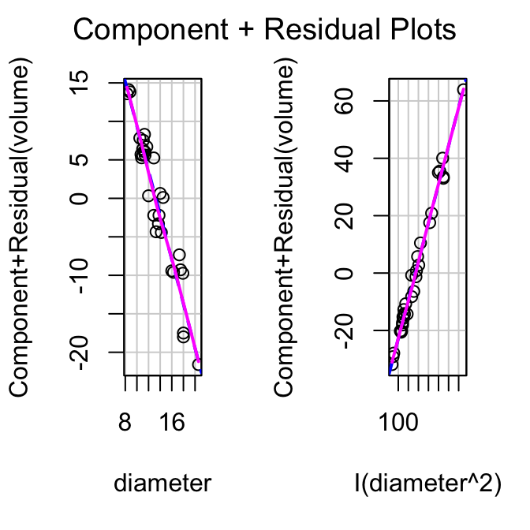

```r
### Fit a model that also has a second degree term for diameter, and make a CPR plots for diameter and diameter^2:
fit.sq=lm(volume~diameter+I(diameter^2)+height, data=trees)

## The plot indicate that the linearity assumption is reasonable both for diameter and diameter^2 (ie. linearity in the parameters)
crPlots(fit.sq,terms=~diameter+I(diameter^2))
```

##### The importance of model assumptions

Non-linearity leads to wrong specification of the systematic part of the model, which can result in:

1. Effect of a predictor may be wrongly estimated
2. Important predictor not detected
3. Serious nonlinearity jeopardizes analysis

##### Model misfit and possible improvements

1. Transform $x_{ji}$, e.g. $log(x_{ji})$
2. Transform $y_{ji}$, e.g. $log(y_{ji})$
3. Include second order term(s) and/or interaction(s)
4. GAM

#### Constant variance (homoscedasticity)

$$Var(\epsilon_i) = \sigma_\epsilon^2 \quad for \space all \space i$$
There should be no systematic patterns in the residuals.

##### Check of homoscedasticity

A plot of the residuals versus the fitted (or predicted) values.

Fan like shape: the variances increase/decrease with expected outcome.

NB. Don’t trust the fitted lines where there is little data.

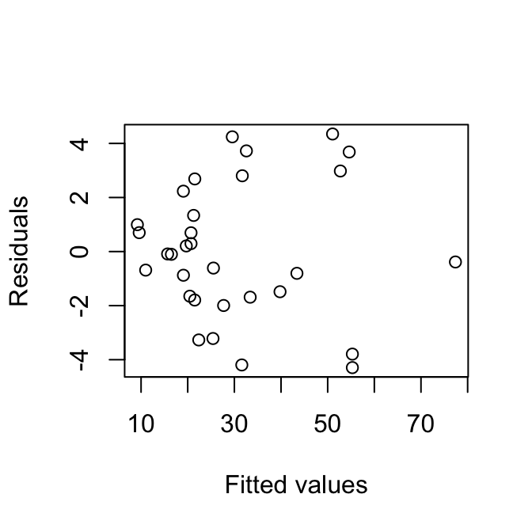

```r
fit.sq=lm(volume~diameter+I(diameter^2)+height, data=trees)

## Reasonable, but some indication of increasing variances
plot(fit.sq$fit, fit.sq$res, xlab="Fitted values", ylab="Residuals")
```

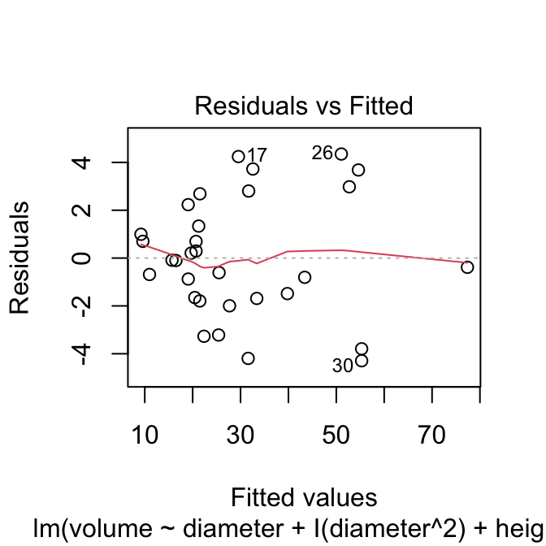

```r
## Added line used to detect pattern in the residuals due to non-linearities
plot(fit.sq,1)
```

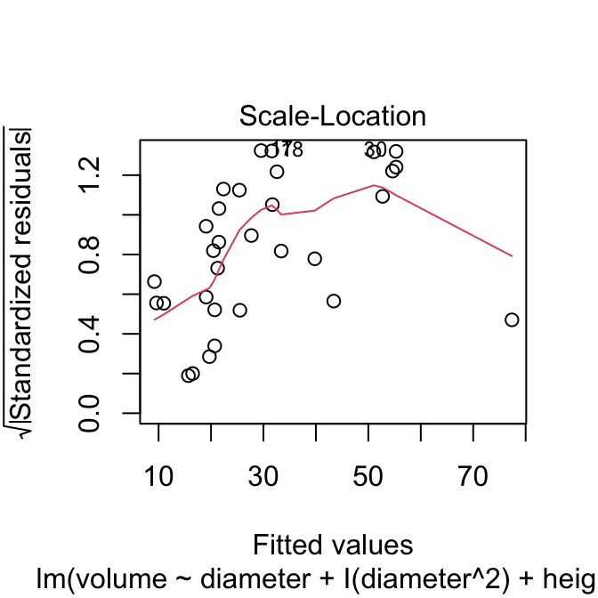

```r
## Added line used to detect increasing variance (or standard deviation)
plot(fit.sq,3)
```

##### The importance of model assumptions

If the variances aren’t equal and/or the errors are correlated:

1. Flawed prediction intervals
2. The estimates of the $\beta_j's$ will be unbiased
3. Wrongly estimated standard errors
4. Flawed CI and p-values

##### Model misfit and possible improvements

1. Transform $x_{ji}$, e.g. $log(x_{ji})$ or $\sqrt{x_{ji}}$
2. Use weighted least-squares
3. GAM

#### Normally distributed errors

The residuals should behave as a sample from a normal distribution with mean zero:

$$\epsilon_i \sim N(0,\sigma_\epsilon^2)$$
##### Check of normality

1. Histogram of residuals
2. Boxplot of residuals
3. Normal Q-Q plot of residuals

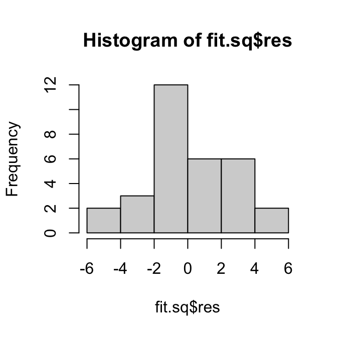

```r
hist(fit.sq$res)
```

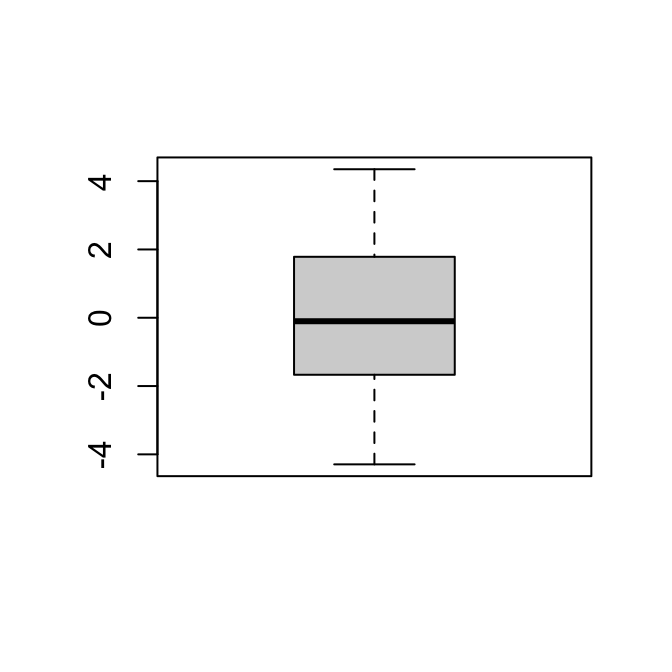

```r
boxplot(fit.sq$res)
```

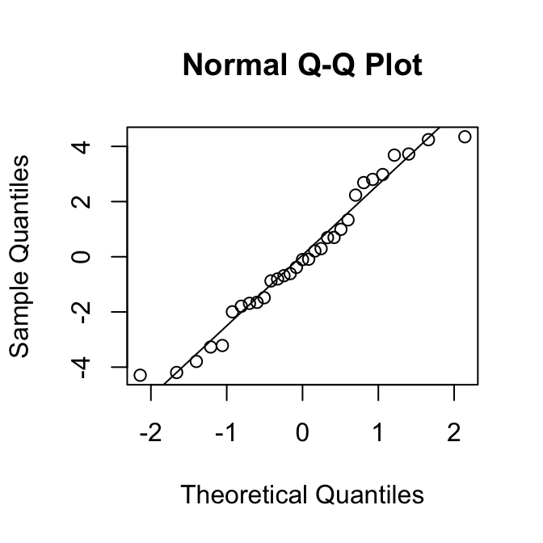

```r
## The Q-Q plot should be close to a straight line if the residuals are normally distributed.
qqnorm(fit.sq$res); qqline(fit.sq$res) ## Alternative: plot(fit.sq,2)
```

##### The importance of model assumptions

If normality not present, but other assumptions true: 1. Valid estimates of standard errors 1. Test statistics are not t- and F-distributed for small n 1. The distributional assumptions are not critical

##### Model misfit and possible improvements

1. Transform $y_i$
2. Bootstrap
3. Ignore problem for large n

#### Influential observations

It’s useful to inspect observations that have a large influence on the estimates.  
A measure for the influence of an observation is the change in the estimate(s) when the model is fitted leaving out the observation:

```r
# fit=lm(erosion~water)
#summary(fit)
# dfbeta(fit)

## dfbetas(fit) with an s gives the standardized dfbetas that may be more appropriate for multiple linear regression when the predictors are on different scales
# dfbetas(fit)
```

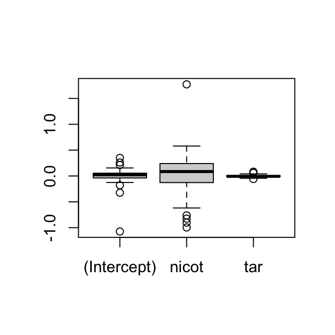

```r
fit.cig=lm(co~nicot+tar,data=cigarettes)
boxplot(dfbeta(fit.cig))
```

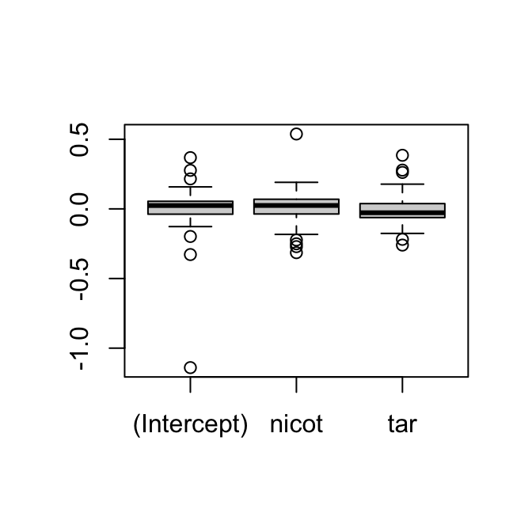

```r
boxplot(dfbetas(fit.cig))
```

##### The importance of model assumptions

- A few influential observations may have large effects on the estimates.
- Critical for conclusions on the relations btw covariates and response.

##### Model misfit and possible improvements

1. Check the coding of the observations
2. Validate the estimates by running the regression without the influential observations

#### Uncorrelated errors

$$Cov(\epsilon_i,\epsilon_j) = 0 \quad for \space all \space i \neq j$$

The importance of model assumptions Model misfit and possible improvements

## Generalized Additive Models (GAM)

1. Extension of linear model
2. CI estimation for estimated curves
3. Test whether there is significant non-linearity in the models

### Model

Assume a general functional dependency on the covariates:

$$\eta_i = \beta_0 + f_1(x_{1i}) + f_2(x_{2i}) + ... + f_p(x_{pi})$$
### Assumptions 1. The functions are smooth: * continuous * have derivatives

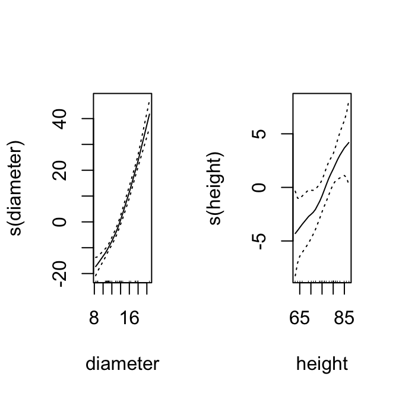

```r
library(gam)
fit.gam.both=gam(volume~s(diameter)+s(height), data=trees)
par(mfrow=c(1,2))
plot(fit.gam.both,se=T)
```

```r
## force the dependency on height to be linear:
fit.gam.dia=gam(volume~s(diameter)+height, data=trees)
```

### Analysis of plots

diameter-function (diameter - s(diameter)):  
Forcing a straight line within the confidence limits impossible $\rightarrow$ significant non-linearity.

height-function (height - s(height)):  
Forcing a straight line within the confidence limits possible $\rightarrow$ no important non-linearity.

### Anova table

```r
fit.gam.dia=gam(volume~s(diameter)+height, data=trees)
anova(fit.both,fit.gam.dia,fit.gam.both)
```

```
## Analysis of Variance Table
##
## Model 1: volume ~ diameter + height
## Model 2: volume ~ s(diameter) + height
## Model 3: volume ~ s(diameter) + s(height)
##   Res.Df RSS Df Sum of Sq     F  Pr(>F)
## 1     28 422
## 2     25 181  3     241.4 10.13 0.00022 ***
## 3     22 175  3       5.8  0.24 0.86402
## ---
## Signif. codes:  0 '***' 0.001 '**' 0.01 '*' 0.05 '.' 0.1 ' ' 1
```

Analysis:

- non-linearity for diameter is significant
- there’s no reason to include a non-linear term for height.

## Selection of predictors

### Objectives:

1. Study one predictor while adjusting for others
2. Identify important predictors for an outcome
3. Predict the outcome for a new unit where only the values of the predictors are available

### Strategies to decide which sub-models to consider

#### Forward selection

1. Fit all *p* models with only one predictor
2. Choose highest-contributing predictor
3. Run *p-1* regressions with this predictor and another
4. Choose the model that “fits” best
5. Continue adding predictors until “no improvement”

#### Stepwise regression

Forward regression, but supplement step 4. with the deletion of predictors that no longer contribute.

#### Backward selection

1. Fit the model with all *p* predictors
2. Compare the model with all predictors with the *p* different models where one predictor has been left out
3. Leave out the “least important predictor”
4. Compare the model obtained with the *p-1* different models where one predictor has been left out
5. Leave out the “least important predictor”
6. Continue until a model is obtained that only contains the “important” predictors

### Criteria for inclusion / exclusion

Possibilities for inclusion of predictors:

P-values

- 5% cutoff often used
- suitable when the object is to study the effect of one predictor, or
- to identify important predictors for an outcome

Ordinary $R^2$

- Draw-back: will always increase when predictors are added.

Adjusted $R^2$

- penalizes including more predictors
- May be used to select predictors as it will have a maximum $R^2$ over the models considered
- Drawback: observations are used twice (estimate the $\beta_j's$ and evaluate the predictions of $y_i's$).

Cross-validated $R^2$

- Cross validation: stimate the regression model without using the observation $y_i$ and predict $\hat{y}_i^{(-i)}$, $y_i$ using the obtained estimates
- May be used to select predictors
- Will often give smaller models than $R_{adj}^2$.

## High dimensional regression

For data with more covariates than observations ($p > n$).

For p <n, in Ordinary Least Squares Regression, we minimize the MSE so that:

$$\hat{\beta} = argmin_{\beta}(y-X\beta)^2$$

### Lasso regression (L1 penalty)

$$\hat{\beta} = argmin_{\beta}(y-X\beta)^2 + \lambda||
\beta||_1$$

Variable selection:

- Leads to shrinkage of the coefficients
- Zeros out the coefficients of the unimpotant variables
- The size of $\lambda$ determines the amount of zero coefficients (may be chosed via K-fold cross-validation)

$$PRSS_y^{lasso}(\beta) = \sum_{i=1}^n(y_i-\beta_0-\sum_{j=1}^px_{ij}\beta_j)^2 + \lambda\sum_{j=1}^p{|\beta_j|}$$

#### Assumptions

Sparsity: only a few of the p covariates matter

```r
library(glmnet)

## Gaussian family because of the continuous response and normal noise
## Alpha = 0 is ridge regression
#cv.fit.lasso=cv.glmnet(x,y,family="gaussian",alpha=1)

## Find lamba value that minimizes the CV-curve
#lambda.min=cv.fit.lasso$lambda.min

## Get the estimated coefficients for lambda.min
#beta.lasso=coef(cv.fit.lasso, s=lambda.min)
```

### Ridge regression (L2 penalty)

$$\hat{\beta} = argmin_{\beta}(y-X\beta)^2 + \lambda||
\beta||_2^2$$

No variable selection:

- shrinks the coefficients:
  - introduces bias
  - reduces variance of the estimators

$$PRSS_y^{ridge}(\beta) = \sum_{i=1}^n(y_i-\beta_0-\sum_{j=1}^px_{ij}\beta_j)^2 + \lambda\sum_{j=1}^p{\beta_j^2}$$

# Lecture 6

## Topics

1. Binary data and proportions (2)
2. Comparing two proportions (5)
3. Contingency tables (10)
4. Excess risk, relative risk, and odds ratio (16)
5. Logistic regression with one predictor (21)
6. Classification (30)

https://www.uio.no/studier/emner/matnat/math/STK4900/v21/lectures/lecture6.pdf

## Binary data and proportions

### Data

$y_i=1$ is subject *i* has a certain property while otherwise $y_i = 0$.

### Finding the proportion in the population

$$\begin{align}
p &= P(y_i=1) \\
&= \text{the proportion in the population } (0 \leq p \leq 1) \\
\hat{p} &= \frac{\sum_{i=1}^n{y_i}}{n} = {n(y_i=1)}{n}
\end{align} \\$$

### Standard errors and confidence intervals

$$se(\hat{p} = \sqrt{\frac{\hat{p}(1-\hat{p})}{n}}) \\
\text{95% CI: } \hat{p} \pm 1.96 \times se(\hat{p})$$

## Comparing two proportions

### Assumptions

1. Random sample of binary data from two populations
2. Two samples are independent

### 95% CI for $p_1-p_2$:

$$\begin{align}
\text{95% CI } &= \hat{p}_1-\hat{p}_2 \pm 1.96 \times se(\hat{p}_1-\hat{p}_2) \\
&= \hat{p}_1-\hat{p}_2 \pm 1.96 \times \sqrt{se(\hat{p}_1)^2+se(\hat{p}_2)^2} \\
&= \hat{p}_1-\hat{p}_2 \pm 1.96 \times \sqrt{\frac{\hat{p}_1(1-\hat{p}_1)}{n_1} + \frac{\hat{p}_2(1-\hat{p}_2)}{n_2}}
\end{align}$$

### Hypothesis testing

$$H_0: p_1 = p_2 \\
H_A: p_1 \neq p_2$$

We reject $H_0$ for large vales of *|z|*:
$$z = \frac{\hat{p}_1-\hat{p}_2}{se_0(\hat{p}_1-\hat{p}_2)} \sim Z-distributed \\
P = 2P(Z>|z|), \text{ where Z is standard normal}$$

## Contingency tables

Formulate the null hypothesis of no difference between population by comparing observed numbers in the table (denoted O’s) with corresponding expected numbers if $H_0$ is true (denoted E’s):

```r
bloodpr=matrix(c(14,11,6,11,11,10,8,9,12),nrow=3)
dimnames(bloodpr)=list(c("F.low","F.middle","F.upper"), c("C.low","C.middle","C.upper"))
bloodpr
```

```
##          C.low C.middle C.upper
## F.low       14       11       8
## F.middle    11       11       9
## F.upper      6       10      12
```

### Find expected values (E)

```r
chisq.test(bloodpr,correct=F)$expected
```

```
##          C.low C.middle C.upper
## F.low     11.1     11.5    10.4
## F.middle  10.4     10.8     9.8
## F.upper    9.4      9.7     8.8
```

### Hypothesis testing

We reject $H_0$ for large values of $X^2$ (chi-square distributed):

$$X^2 = \sum_{all cells}{\frac{(O-E)^2}{E}} \sim (rows-1) \times (columns-1) \space df \\
P-value: P(X^2 \geq X_{obs}^2)$$

```r
chisq.test(bloodpr,correct=F)
```

```
##
##  Pearson's Chi-squared test
##
## data:  bloodpr
## X-squared = 4, df = 4, p-value = 0.4
```

We can test the null hypothesis that there is no difference between the groups with a table.

## Excess risk, relative risk, and odds ratio

### Assumptions

1. Random sample of binary data
2. Independent samples
3. Population 1 corresponds to an “exposed” population (x = 1)
4. Population 2 corresponds to an “unexposed” population (x = 0)

### Data

Population 1: $p_1 = p(1) = P(y=1|x=1)$ Population 2: $p_2 = p(0) = P(y=1|x=0)$

### Excess and relative risk

Excess risk (ER): measure of the effect of the “exposure” Relative risk (RR): measure of the effect of the “exposure”

$$\begin{align}
ER &= p(1) - p(0) = \hat{p}_1 - \hat{p}_2 \\
RR &= \frac{p(1)}{p(0)} = \frac{\hat{p}_1}{\hat{p}_2}
\end{align}$$

### Odds

$$odds = \frac{p}{1-p} \\
odds(population 1): \frac{p(1)}{1-p(1)} = \frac{P(y=1|x=1)}{1-P(y=1|x=1)} \\
odds(population 2): \frac{p(0)}{1-p(0)} = \frac{P(y=1|x=0)}{1-P(y=1|x=0)} \\$$

### Odds ratio

#### Interpretation

$OR=1:$ Exposure does not affect odds of outcome $OR>1:$ Exposure associated with higher odds of outcome $OR<1:$ Exposure associated with lower odds of outcome

#### Importance

1. Turns up in logistic regression
2. Related to relative risk:
- $RR=1 \rightarrow OR=1$
- $RR>1 \rightarrow 1<RR<OR$
- $RR<1 \rightarrow OR<RR<1$
- $p(1) << 1, \space p(0) <<1 \rightarrow OR \approx RR$

$$OR = \frac{\frac{p(1)}{1-p(1)}}{\frac{p(0)}{1-p(0)}}$$

## Logistic regression with one predictor

Model that specifies a relation between p(x) and x:

$$p(x) = E(y|x) = P(y=1|x)$$

### Example

How does the age (at entry to the study) affect the risk (probability) of developing coronary heart disease (CHD)?

### Data

$(x_1,y_1),...,(x_n,y_n)$, where $y_i$ is a binary outcome (0 or 1) for subject *i* and $x_i$ is a predictor for the subject (binary/numerical).

### Logistic regression model

$$p(x) = \frac{exp(\beta_0+\beta_1x)}{1+exp(\beta_0+\beta_1x)} = \frac{{e^{\beta_0 + \beta_1x}}}{1+e^{\beta_0 + \beta_1x}}$$

Suitable because it gives $0 \leq p \leq 1$, whereas a additive risk model (linear model), $p(x) = \beta_0+\beta_1x$ give impossible values for the probabilities.

### Relation to odds

The odds ratio, $e^{\beta_1}$, corresponds to one unit’s increase in the value of the covariate.

$$\begin{align}
odds &= \frac{p(x)}{1-p(x)} \\
&= e^{\beta_0+\beta_1x}
\end{align}$$
Consider two subjects with covariate values $x+\Delta$ and $x$:

$$\begin{align}
odds \space ratio &= \frac{\frac{p(x+\Delta)}{1-p(x+\Delta)}}{\frac{p(x)}{1-p(x)}} \\
&= \frac{e^{\beta_0+\beta_1(x+\Delta)}}{e^{\beta_0+\beta_1x}} \\
&= e^{\beta_1\Delta}
\end{align}$$

### R commands for logistic regression

Both ways of fitting the logistic regression model give the same estimates and standard errors.

#### Binary data

```r
## Using the individual binary data
wcgs=read.table("http://www.uio.no/studier/emner/matnat/math/STK4900/data/wcgs.txt",sep="\t",header=T,na.strings=".")

wcgs$agem=
  39.5*(wcgs$agec==0)+
  42.9*(wcgs$agec==1)+
  47.9*(wcgs$agec==2)+
  52.8*(wcgs$agec==3)+
  57.3*(wcgs$agec==4)
attach(wcgs)
# cbind(chd69, agem)

fit.binary=glm(chd69~agem,
               data=wcgs,
               family=binomial)
# summary(fit.binary)
predict(fit.binary,
        type = 'response',
        data.frame(agem=50)) # predicts prob. at age 50
```

```
##     1
## 0.099
```

#### Grouped data

Uses mean value in each group as a covariate.

```r
## Grouped data
chd.grouped=read.table("http://www.uio.no/studier/emner/matnat/math/STK4900/data/chd_grouped.txt ", header=T)
chd.grouped
```

```
##     no chd agem
## 1  543  31   40
## 2 1091  55   43
## 3  750  70   48
## 4  528  65   53
## 5  242  36   57
```

```r
fit.grouped=glm(cbind(chd,no-chd)~agem,
                data=chd.grouped,
                family=binomial)
# summary(fit.grouped)
```

### Interpretation

$OR = e^{\beta_1}$ is the odds ratio for one unit increase in *x*.

### Confidence interval for beta<sub>1</sub> and odds ratio

$$\begin{align}
\text{95% CI for } \beta_1 &= \hat{\beta}_1 \pm 1.96 \times se(\hat{\beta}_1) \\
&= \hat{\beta}_1 - 1.96 \times se(\hat{\beta}_1)
\leq \hat{\beta}_1
\leq \hat{\beta}_1 + 1.96 \times se(\hat{\beta}_1) \\
\text{95% CI for } OR &: e^{\hat{\beta}_1 - 1.96 \times se(\hat{\beta}_1)} \leq OR \leq e^{\hat{\beta}_1 - 1.96 \times se(\hat{\beta}_1)}\\
\end{align}$$

### R commands

```r
wcgs=read.table("http://www.uio.no/studier/emner/matnat/math/STK4900/data/wcgs.txt",sep="\t",header=T,na.strings=".")
fit=glm(chd69~age, data=wcgs,family=binomial)
expcoef <- function(glmobj) {
  regtab=summary(glmobj)$coef
  expcoef=exp(regtab[,1])
  lower=expcoef*exp(-1.96*regtab[,2])
  upper=expcoef*exp(1.96*regtab[,2])
  cbind(expcoef,lower,upper)
}
expcoef(fit)
```

```
##             expcoef  lower  upper
## (Intercept)  0.0026 0.0009 0.0077
## age          1.0773 1.0537 1.1014
```

### Hypothesis testing - Wald test

$$H_0: \beta_1 = 0 \\
H_A: \beta_1 \neq 0$$

We reject $H_0$ for large values of |z|:

## Classification

Logistic regression is a classifier, because a model can predict a categorical response.

$$p(x) = \frac{{e^{\beta_0 + \beta_1x}}}{1+e^{\beta_0 + \beta_1x}} \\
p(x) \geq 0.5 = \beta_0 + \beta_1x \geq 0 \rightarrow y=1 \\
p(x) < 0.5 = \beta_0 + \beta_1x < 0 \rightarrow y=0 \\$$

Extending to two predictors x<sub>1</sub> and x<sub>2</sub>:

$$p(x) = \frac{{e^{\beta_0 + \beta_1x_1 +\beta_2x_2}}}{1+e^{\beta_0 + \beta_1x_1 +\beta_2x_2}} \\
p(x) \geq 0 = \beta_0 + \beta_1x_1 + \beta_2x_2 \geq 0 \rightarrow y=1 \\$$

### Other common classification methods

1. Linear discriminant analysis (LDA)
- assumes that predictors are normally distributed
1. K-nearest neighbours (KNN)
- Non-parametric
1. Generalized additive reading
2. Tree-based methods
3. Random forests
4. Boosting
5. Support vector machines (SVM)

# Lecture 7

## Topics

1. Maximum likelihood estimation (5)
2. Multiple logistic regression (12)
3. Deviance and likelihood ratio tests (21)
4. Model fit (29)

https://www.uio.no/studier/emner/matnat/math/STK4900/v21/lectures/lecture7.pdf

## Maximum likelihood estimation (5)

### Maximum likelihood estimates

We estimate the parameters, $\hat{\beta_0}$ and $\hat{\beta_1}$, in the logistic model by maximizing the likelihood (making the $y_i$ as likely as possible).

The likelihood is the simultaneous density considered as a function of the parameters $\beta_0$ and $\beta_1$ for the observed values of $y_i$:

$$L = \prod_{i=1}^n P(y_i | x_i) = \prod_{i=1}^n p_i^{y_i} (1-p_i)^{1-y_i}$$

### MLE and linear regression

For linear regression models, maximum likelihood estimation coincides w/ least squares estimation because maximizing the likelihood L is the same as maximizing

$$log(L) = -\frac{n}{2} log(2\pi\sigma^2) - \frac{1}{2 \sigma^2} \sum_{i=1}^n (y_i - \mu_i)^2$$

and minimizing

$$\sum_{i=1}^n {(y_i - \mu_i)^2}$$

## Multiple logistic regression

### Data

Each subject has: 1. A binary outcome y 1. Predictors $x_1, x_2, ..., x_p$

$$\begin{align}
p(x_1, x_2, ..., x_p) &= E(y|x_1, x_2, ..., x_p) \\
&= P(y=1|x_1, x_2, ..., x_p) \\
&= \frac{e^{\beta_0 + \beta_1x_1 + \beta_2x_2 + ... + \beta_px_p}}{1 + e^{\beta_0 + \beta_1x_1 + \beta_2x_2 + ... + \beta_px_p}}
\end{align}$$

In terms of odds:

$$\frac{p(x_1, x_2, ..., x_p) }{1 - p(x_1, x_2, ..., x_p)} = e^{\beta_0 + \beta_1x_1 + \beta_2x_2 + ... + \beta_px_p}$$

The odds ratio $e^{\beta_j}$ is the odds ratio corresponding to one unit’s increase in the value of the j-th covariate *holding all other covariates constant*.

$$\begin{align}
odds \space ratio &= \frac{\frac{p(x_1 + \Delta, x_2, ..., x_p) }{1 - p(x_1 + \Delta, x_2, ..., x_p)}}{\frac{p(x_1, x_2, ..., x_p) }{1 - p(x_1, x_2, ..., x_p)}} \\
&= \frac{e^{\beta_0 + \beta_1(x_1 + \Delta) + \beta_2x_2 + ... + \beta_px_p}}{e^{\beta_0 + \beta_1x_1 + \beta_2x_2 + ... + \beta_px_p}} \\
&= e^{\beta_1 \Delta}
\end{align}$$

### Hypothesis testing - Wald test

$$H_{0j}: \beta_j = 0 \\
H_{Aj}: \beta_j \neq 0$$

We reject $H_0$ for large values of |z|:

$$\begin{align}
z &= \frac{\hat{\beta}_j}{se(\hat{\beta}_1)} \sim N(0,1) \\
p &: P = 2P(Z>|z|) \\
\text{95% CI for } \beta_j &= \beta_j \pm 1.96 \times se(\hat{\beta}_j) \\
&= \hat{\beta}_j - 1.96 \times se(\hat{\beta}_j)
\leq \hat{\beta}_j
\leq \hat{\beta}_j + 1.96 \times se(\hat{\beta}_j) \\
\text{95% CI for } OR &= e^{\hat{\beta}_j - 1.96 \times se(\hat{\beta}_j)} \leq OR \leq e^{\hat{\beta}_j - 1.96 \times se(\hat{\beta}_j)}\\
\end{align}$$

```r
wcgs=read.table("http://www.uio.no/studier/emner/matnat/math/STK4900/data/wcgs.txt",sep="\t",header=T,na.strings=".")
wcgs.mult=glm(chd69~age+chol+sbp+bmi+smoke,
              data=wcgs,
              family=binomial,
              subset=(chol<600))
# summary(wcgs.mult)
## Odds ratios with CI
# expcoef(wcgs.mult)
```

[output not shown]

Used to assess the fit of a logistic model (corresponding to sum of squares for linear regression) by comparing deviances in two models.

### Deviance of a fitted model

Denoted “residual deviance” in the output.

$$\begin{align}
D &= 2(\tilde{l} - \hat{l}) \\
&= \frac{1}{\sigma^2} \sum_{i=1}^n (y_i - \hat{\mu}_i)^2
\end{align}$$

For the saturated model (model with no restrictions on the p<sub>i</sub>), the p<sub>i</sub> are estimated by $\tilde{p}_i = y_i$ and the log-likelihood takes the value $\tilde{l} = l(\tilde{p}_i, ..., \tilde{p}_n)$

### Null deviance

The deviance for the model with no covariates, i.e. for the model where all the p<sub>i</sub> are assumed to be equal.

### Hypothesis testing

$$H_0: \text{q of the }\beta_j's = 0$$

We reject $H_0$ for large values of the test statistic, G:
$$G = D_0 - D \sim X^2 \text{ with q df under } H_0$$

### G in terms of the likelihood ratio

$$\begin{align}
D = 2(\tilde{l}-\hat{l}) \quad &and \quad D_0 = 2(\tilde{l}-\hat{l}_0) \\
\hat{l} = log(\hat{L}) \quad &and \quad \hat{l}_0 = log(\hat{L}_0) \\
\hat{L} = max_{model}L \quad &and \quad \hat{L}_0 = max_{H_0} L
\end{align}$$

$$\begin{align}
Thus, \\
G &= D_0 - D \\
&= 2(\tilde{l}-\hat{l}_0) - 2(\tilde{l}-\hat{l}) = -2(\hat{l}_0-\hat{l}) \\
&= -2 log(\frac{\hat{L}_0}{\hat{L}})
\end{align}$$

Thus large values of G corresponds to small values of the likelihood ratio $\frac{\hat{L}_0}{\hat{L}}$ and the test based on G is equivalent to the likelihood ratio test.

```r
wcgs.resc=glm(
  chd69~age_10+chol_50+sbp_50+bmi_10+smoke,
  data=wcgs,
  family=binomial,
  subset=(chol<600))
#summary(wcgs.resc)
anova(wcgs.resc,wcgs.beh,test="Chisq")
```

```
## Analysis of Deviance Table
##
## Model 1: chd69 ~ age_10 + chol_50 + sbp_50 + bmi_10 + smoke
## Model 2: chd69 ~ age_10 + chol_50 + sbp_50 + bmi_10 + smoke + behcat
##   Resid. Df Resid. Dev Df Deviance Pr(>Chi)
## 1      3135       1614
## 2      3132       1590  3     24.8  1.7e-05 ***
## ---
## Signif. codes:  0 '***' 0.001 '**' 0.01 '*' 0.05 '.' 0.1 ' ' 1
```

### Interpretation

- Deviance = 1589.6
- For the model without behavioral pattern, the deviance takes the value $D_0 = 1614.4$
- $G = D_0 - D = 1614.4 - 1589.6 = 24.8$
- $P-value << 0.05 $ behavioral pattern is significant predictor of coronary heart disease.

## Model fit for logistic regression

### Model assumptions

- Linearity
- Heteroscedastic model, $Var(y_i | x_i) = p_i(1-p_i)$ (ie. depends on $E(y_i | x_i) = p_i$)
- Independent responses
- Normally distributed error terms and no outliers (not relevant (binary responses))

### Checking linearity for logistic regression

$$log(\frac{p(x_1, x_2, ..., x_p) }{1 - p(x_1, x_2, ..., x_p)})
= \beta_0 + \beta_1x_1 + \beta_2x_2 + ... + \beta_px_p$$

#### Approaches:

Grouping the covariates

- Use a deviance test and anova to check if categorical models give better fits than the numerical model:
- e.g. consider age group as a factor
- e.g. use the mean age in each age group as a numerical covariate

Adding square terms or logarithmic terms to the model

- Use a deviance test and anova to check if flexible models give a better fit than the original:
- e.g. add $\beta_2x^2$ or $\beta_2 log(x)$ terms

Extending the model to generalized addiive models

- $log(\frac{p(x_1)}{1-p(x_1)}) = \beta_0 + f_1(x_1)$ where $f_1(x_1)$ is a smooth function estimated by the program
- plot the estimated function with confidence intervals
- compare the simple and flexible model by a deviace test

### Deviance and grouped data

Residual deviance and the null deviance are not the same when we use binary data and grouped data.

The difference between the two, however, is the same in both cases.

As long as we look at the differences between deviances, it does not matter whether we use binary or grouped data.

# Lecture 8

## Topics

1. Poisson distribution (3)
2. Poisson regression (14)
3. Generalized linear models (24)

https://www.uio.no/studier/emner/matnat/math/STK4900/v21/lectures/lecture8.pdf

## Poisson distribution

### The Poisson distribution

An appropriate model for “rare events” that are happening “randomly over time/space”

Arises as:

- an approximation to the distribution of $Y \sim \binom {n}{p}$ when *p* is small and *n* is large ($\lambda = np$)
- from a Poisson process

$$P(Y=y) = \frac{\lambda^y}{y!} e^{-\lambda}, \quad y = 0,1,2,... \\
Y \sim Po(\lambda) \\
E(Y) = Var(Y) = \lambda$$

### Poisson approximation to the binomial distribution

$$\binom{n}{p} p^y (1-p)^{n-y} \approx \frac{\lambda^y}{y!} e^{-\lambda}$$

### Poisson process

#### Time

Let Y be the number of events in an interval of length t:

$$Y \sim Po(\lambda t)$$

##### Assumptions

1. the rate of events is constant over time (rate = expected number of events per unit of time)
2. the number of events in disjoint time-intervals are independent
3. events do not occur together

#### Space

Let Y be the number of events in an area of size a:

$$Y \sim Po(\lambda a)$$

### Overdispersion

The expected value and variances are both estimates of and therefore approximately equal:

$$\bar{y} = \frac{1}{n} \sum_{i=1}^n y_i \\
s^2 = \frac{1}{n-1} \sum_{i=1}^n (y_i - \bar{y})^2$$

#### Coefficient of dispersion

$$CD = \frac{s^2}{\bar{y}} \\
CD >> 1 \rightarrow overdispersion$$

#### Correction for overdispersion

We can allow for overdispersion by specifying a model $Var(Y_i) = \phi V (\mu_i)$, where $V (\mu)$ is the variance function (see notes on GLMs).

Overdispersed Poission model given by:

$$\begin{align}
log(\mu_i) &= \beta_0 + \beta_1x_{1i} + \beta_2x_{2i} + ... + \beta_px_{pi} \\
Var(Y_i) &= \phi \mu_i
\end{align}$$

Correction of standard errors: $se* = se \sqrt{\hat{\phi}}$ Correction of z-values: $z* = \frac{z}{\sqrt{\hat{\phi}}}$

#### Implementation in R (quasi-likelihood)

```r
glm(
  partners~Gender+Married+factor(HIVtest)+factor(agegr),
  family=quasi(link=log,
               var="mu"),
  data=part)
```

### Test of Poisson distribution

Data: $y_1, y_2, ..., y_n$ Null: $H_0: $ data are Poisson distributed

$$X^2 = \sum{\frac{(O_j - E_j)^2}{E_j}} \sim K-2$$

If $p > 0.25$, the Poisson distribution fits nicely to the data.

## Poisson regression

$$\begin{align}
\lambda_{i} &= \lambda(x_{1i}, x_{2i}, ..., x_{pi}) \\
&= e^{\beta_0 + \beta_1x_{1i} + \beta_2x_{2i}+...+\beta_px_{pi}}
\end{align}$$

### Data

$$y_i, x_{1i}, x_{2i},...,x_{pi} \quad i=1,...,n \\
\begin{align}
y_i &= \text{a count for subject } i \\
x_{ji} &= \text{predictor (covariate) j for subject i}
\end{align}$$

### Assumptions

- responses $y_i$ are realizations of independent Poisson distributed random variables $Y_i \sim Po(\lambda_i)$
- $\lambda_i = \lambda(x_{1i}, x_{2i}, ..., x_{pi})$ is a function of the covariates

### Rate ratio (RR)

$e^{\beta_1 \Delta}$ is the rate ratio corresponding to one unit’s increase in the value of the first covariate *holding all other covariates constant*

$$\begin{align}
RR &= \frac{\lambda(x_1 + \Delta, x_2, ..., x_p)}{\lambda(x_1, x_2, ..., x_p)} \\
&= \frac{
exp(\beta_0 + \beta_1(x_{1} + \Delta) + \beta_2x_{2}+...+\beta_px_{p})}
{exp(\beta_0 + \beta_1x_{1} + \beta_2x_{2}+...+\beta_px_{p})} \\
&= e^{\beta_1 \Delta}
\end{align}$$

### Aggregated counts (grouped)

An observation *y<sub>i</sub>* is a realization of $Y_i \sim Po(w_i \lambda_i)$ where the weight *w<sub>i</sub>* is the number of subjects in group <sub>i</sub>.

$$\begin{align}
E(Y_i) &= w_i \lambda_i \\
&= w_i exp(\beta_0 + \beta_1x_{1i} + \beta_2x_{2i} + ... + \beta_px_{pi}) \\
&= exp(log(w_i) + \beta_0 + \beta_1x_{1i} + \beta_2x_{2i} + ... + \beta_px_{pi})
\end{align} \\
log(w_i) \text{ is an offset: a covariate where the regression coefficient is known to equal 1}$$

```r
fit.claims=glm(
  acc~offset(log(num))+factor(age)+factor(vol),
  data=car.claims,
  family=poisson)

summary(fit.claims)
```

[output not shown]

### Interpretation

- $e^{\hat{\beta_0}} = e^{-1.916} = 0.147$ is the expected number of claims for a driver with age < 30y with a small car.
- $e^{\hat{\beta_1}} = e^{-0.376} = 0.687$ is the rate ratio for a driver aged $\geq$ 30y *compared with a driver younger than 30 years (with same car type)*.

### Maximum likelihood estimation

$$P(Y_i = y_i) = \frac{(w_i \lambda_i)^{y_i}}{y_i!} exp(-w_i \lambda_i) \\$$

#### Likelihood

$$\text{Likelihood is the simultaneous distribution: }\\
L = \prod_{i=1}^n \frac{(w_i \lambda_i)^{y_i}}{y_i!} exp(-w_i \lambda_i) \\
\text{considered as a function of the parameters } \beta_0, \beta_1, ..., \beta_p \text{ for the observed values of the } y_i \\$$

#### Maximum likelihood estimates (MLE)

$$\hat{\beta_0}, \hat{\beta_1}, ..., \hat{\beta_p} \rightarrow max(L) = max(l = log(L))$$

### Wald tests and confidence intervals

$$\begin{align}
\hat{\beta_j} &= MLE \space for \space \beta_j \\
se(\hat{\beta_j}) &= standard \space error \space for \hat{\beta_j} \\
\end{align}$$
#### Wald test statistic

$$\begin{align}
H_{0j} &: \beta_j = 0 \\
z &= \frac{\hat{\beta_j}}{se(\hat{\beta_j})} \sim N(0,1)
\end{align}$$

#### 95% confidence interval

$$\hat{\beta_j} \pm 1.96 \times se(\hat{\beta_j}) \\
e^{\hat{\beta_j} \pm 1.96 \times se(\hat{\beta_j})} \leq RR \leq e^{\hat{\beta_j} \pm 1.96 \times se(\hat{\beta_j})}$$

```r
## Rate ratios with CI
expcoef <- function(glmobj) {
  regtab=summary(glmobj)$coef
  expcoef=exp(regtab[,1])
  lower=expcoef*exp(-1.96*regtab[,2])
  upper=expcoef*exp(1.96*regtab[,2])
  cbind(expcoef,lower,upper)
}

expcoef(fit.claims)
```

```
##              expcoef lower upper
## (Intercept)     0.15  0.13  0.16
## factor(age)2    0.69  0.63  0.75
## factor(vol)2    1.28  1.16  1.40
## factor(vol)3    1.77  1.53  2.04
```

### Deviance and likelihood ratio tests

$H_0: q$ of the $B_j's = 0$, or equivalently,  
$H_0:$ there are *q* linear restrictions among the $B_j's$

#### Log likelihoods

$$\begin{align}
l &= \text{the maximum possible value of the log-likelihood, obtained for the saturated model with no restriction on the } \lambda_i \\
\hat{l} &= log \hat{L} \text{ is the log-likelihood for the full Poisson regression model} \\
\hat{l_0} &= log \hat{L_0} \text{ is the log-likelihood under } H_0 \\
\end{align}$$

Deviance and test statistic

$$\begin{align}
D &= 2(l-\hat{l}) \quad and \quad D_0 = 2(l-\hat{l}_0) \\
G &= D_0 - D \sim X^2, \space q \space df\\
&= -2 log (\frac{\hat{L_0}}{\hat{L}})
\end{align}$$

```r
fit.null=glm(
  acc~offset(log(num)),
  data=car.claims,
  family=poisson)

fit.age=glm(
  acc~offset(log(num))+factor(age),
  data=car.claims,
  family=poisson)

fit.age.vol=glm(
  acc~offset(log(num))+factor(age)+factor(vol),
  data=car.claims,
  family=poisson)

fit.interaction=glm(
  acc~offset(log(num))+factor(age)+factor(vol) +factor(age):factor(vol),
  data=car.claims,family=poisson)

anova(fit.null,
      fit.age,
      fit.age.vol,
      fit.interaction,
      test="Chisq")
```

[output not shown]

## Generalized linear models (GLMs)

### Common GLMs:

1. Multiple linear regression
2. Logistic regression
3. Poisson regression

### Parts of GLMs:

A family of distributions

- Poisson: observations Y<sub>i</sub> are independent and Poisson distributed with means $\mu_i = E(Y_i)$
- MLR: normal

A linear predictor

- Poisson: a linear expression in regression and covariates, $\eta_i = \beta_0 + \beta_1x_{1i} + \beta_2x_{2i} + ... + \beta_px_{pi}$
- MLR:

A link function

NB. Other link functions may be specified (slide 26).

### Statistical inference

Estimation: maximum likelihood (MLE) Testing:

1. Wald tests
2. Deviance / likelihood ratio tests

### Variance function

Describe how the variance depends on the mean .  
Specific for each family of distributions.

$$Poisson: V(\mu) = \mu \\
Binary \space data: V(\mu) = \mu(1 - \mu) \\
Normal \space data: V(\mu) = 1 \\$$

$V(\mu) = 1$ for normal data because the variance doesn’t depend on the mean, thus $Var(Y_i) = \sigma^2 = \sigma ^ 2 V (\mu_i)$.

### Heteroscedastic linear model

Assume:

1. an acceptable linear structure, $E(Y_i) = \mu_i = \beta_0 + \beta_1x){1i} + \beta_2x_{2i} + ... + \beta_px_{pi}$
2. a non-constant variance that depended on $\mu_i$, $Var(Y_i) \approx \phi\mu_i$

Solution: specify a quasi-likelihood model with identitiy link and variance function $\mu$ in R.

## Generalized additive models (GAM)

An extension of GLMs.

### Parts of GAMs

1. A family of distributions
2. A link function
3. An additive predictor, $\eta_i = \beta_0 + f_1(x_{1i}) + f_2(x_{2i}) + ... + f_p(x_{pi})$

Use the GAM library (R examples lecture 5, slide 19 and lecture 7, slide 35).

# Lecture 9

## Topics

1. Survival data and censoring (3)
2. Survival function and hazard rate (14)
3. Kaplan-Meier Estimation (24)
4. Logrank test
5. Proportional hazards and Cox regression

https://www.uio.no/studier/emner/matnat/math/STK4900/v21/lectures/lecture9.pdf

## Survival data and censoring